# Some analyses on PhD graduates in Canada

Ming Ming Zhang

2019-04-15

## Abstract

We are interested in some statistics on PhD graduates in Canada, specially in population of PhD graduates and who pursued further education after PhD graduation. The data is extracted from [National graduates survey, postsecondary graduates by province of study and level of study, Table 37-10-0030-01, Statistics Canada](https://www150.statcan.gc.ca/t1/tbl1/en/tv.action?pid=3710003001).

Our analyses show that the population of PhD graduates in Canada had a decrease from 2000 to 2005, and an increase from 2005 to 2010. In particular, British Columbia had the most decrease from 2000 to 2005; Quebec had the most growth from 2005 to 2010; and from 2000 to 2010, Saskatchewan had the most growth.

Interestingly, in the population of PhD graduates in Canada, there are some graduates who pursued further education after graduation. We found that the PhD graduates in Alberta who pursued further education after graduation is the only province in Canada had a decrease from 2000 to 2010; in the contrast, British Columbia and Ontario shared the most growth. The results are interpreted as geographic patterns in the map of Canada.

## Analyses

```r
grad = read.csv("~/Documents/Data.Science/Computing.Data/graduates.csv")

head(grad)
```

```
##   REF_DATE    GEO          DGUID Level.of.study
## 1     2000 Canada 2016A000011124        College
## 2     2000 Canada 2016A000011124        College
## 3     2000 Canada 2016A000011124        College
## 4     2000 Canada 2016A000011124        College
## 5     2000 Canada 2016A000011124        College
## 6     2000 Canada 2016A000011124        College
##                                   Statistics        UOM UOM_ID
## 1                        Number of graduates     Number    223
## 2                                    Females    Percent    239
## 3                  Average age at graduation      Years    308
## 4                   Median age at graduation      Years    308
## 5                 Under age 25 at graduation    Percent    239
## 6 Pursued further education after graduation Percentage    242
##   SCALAR_FACTOR SCALAR_ID    VECTOR COORDINATE  VALUE STATUS SYMBOL
## 1        units          0 v90469943      1.1.1 101400            NA
## 2        units          0 v90469944      1.1.2     57            NA
## 3        units          0 v90469945      1.1.3     27            NA
## 4        units          0 v90469946      1.1.4     23            NA
## 5        units          0 v90469947      1.1.5     59            NA
## 6        units          0 v90469948      1.1.6     26            NA
##   TERMINATED DECIMALS
## 1         NA        0
## 2         NA        0
## 3         NA        0
## 4         NA        0
## 5         NA        0
## 6         NA        0
```

```r
G = grad[,c(1,2,4,5,6,12)]

G = subset(G, Level.of.study=="Doctorate" & (Statistics=="Number of graduates" | Statistics=="Pursued further education after graduation"))

G = G[,-c(3,4)]

head(G)
```

```
##    REF_DATE                       GEO        UOM VALUE
## 19     2000                    Canada     Number  4200
## 24     2000                    Canada Percentage    11
## 43     2000 Newfoundland and Labrador     Number     0
## 48     2000 Newfoundland and Labrador Percentage    NA
## 67     2000      Prince Edward Island     Number     0
## 72     2000      Prince Edward Island Percentage    NA
```

```r
G$GEO = factor(G$GEO, levels = c("Canada","Alberta","British Columbia","Manitoba","New Brunswick","Newfoundland and Labrador","Nova Scotia","Ontario","Prince Edward Island","Quebec","Saskatchewan"))
```

We use the following abbreviations for provinces and territories.

```r
G$GEO1 = factor(G$GEO, levels = c("Canada","Alberta","British Columbia","Manitoba","New Brunswick","Newfoundland and Labrador","Nova Scotia","Ontario","Prince Edward Island","Quebec","Saskatchewan"), labels = c("CA","AB","BC","MB","NB","NL","NS","ON","PE","QC","SK"))
```

Let $Population\; I$ denote the number of PhD graduates in certain year.

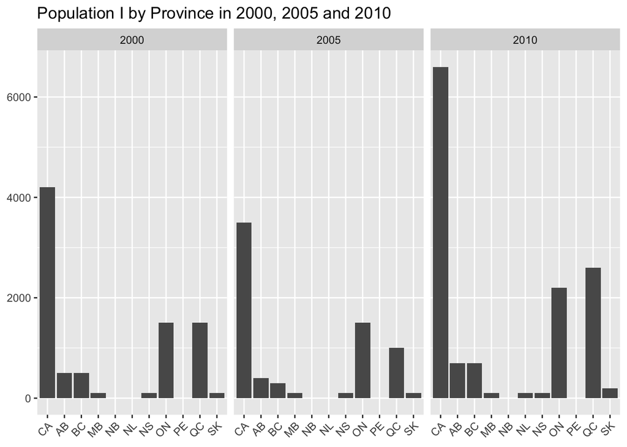

```r
library(ggplot2)

ggplot(G[G$UOM=="Number",],aes(x=GEO1,y=VALUE)) +
  geom_bar(stat = "identity") +
  theme(axis.text.x=element_text(angle=45,hjust=1),axis.title.x=element_blank(),axis.title.y=element_blank()) +
  facet_grid(~REF_DATE) +
  labs(title = "Population I by Province in 2000, 2005 and 2010")
```

The above figure shows that Canada had a decrease in $Population\; I$ from 2000 to 2005, and Canada had an increase in $Population\; I$ from 2005 to 2010.

Let $Population\; II$ denote the number of PhD graduates pursued further education after graduation in certain year. When we say $percentage\; Population\; II$, we mean percentage of $Population\; II$ in $Population\; I$.

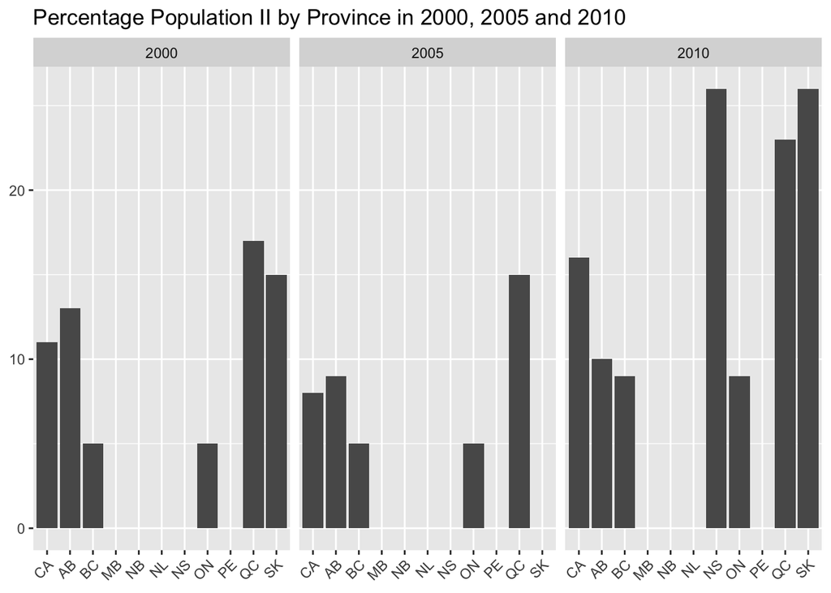

```r
ggplot(G[G$UOM=="Percentage",],aes(x=GEO1,y=VALUE)) +
  geom_bar(stat = "identity") +
  theme(axis.text.x=element_text(angle=45,hjust=1),axis.title.x=element_blank(),axis.title.y=element_blank()) +
  facet_grid(~REF_DATE) +
  labs(title = "Percentage Population II by Province in 2000, 2005 and 2010")
```

It follows that Canada had a decrease in $Population\; II$ from 2000 to 2005, and Canada had an increase in $Population\; II$ from 2005 to 2010.

Next we will investigate the changes in $Population\; I$ and $II$ by province.

```r
G2000 = G[G$REF_DATE==2000,]

G2000 = G2000[,-1]

names(G2000)[3] = "V2000"

G2005 = G[G$REF_DATE==2005,]

G2005 = G2005[,-1]

names(G2005)[3] = "V2005"

G2010 = G[G$REF_DATE==2010,]

G2010 = G2010[,-1]

names(G2010)[3] = "V2010"
```

```r
G1 = merge(merge(G2000,G2005),G2010)

G1 = G1[order(G1$GEO),]

head(G1)
```

```
##                GEO        UOM GEO1 V2000 V2005 V2010
## 5           Canada     Number   CA  4200  3500  6600
## 6           Canada Percentage   CA    11     8    16
## 1          Alberta     Number   AB   500   400   700
## 2          Alberta Percentage   AB    13     9    10
## 3 British Columbia     Number   BC   500   300   700
## 4 British Columbia Percentage   BC     5     5     9
```

We calculate the percentage of changes in $Population\; I$ and $II$ as follows.

```r
G1$`C2000-05` = ifelse(G1$V2000==0,NA,(G1$V2005 - G1$V2000)/G1$V2000)
G1$`C2005-10` = ifelse(G1$V2005==0,NA,(G1$V2010 - G1$V2005)/G1$V2005)
G1$`C2000-10` = ifelse(G1$V2000==0,NA,(G1$V2010 - G1$V2000)/G1$V2000)

head(G1)
```

```
##                GEO        UOM GEO1 V2000 V2005 V2010   C2000-05  C2005-10
## 5           Canada     Number   CA  4200  3500  6600 -0.1666667 0.8857143
## 6           Canada Percentage   CA    11     8    16 -0.2727273 1.0000000
## 1          Alberta     Number   AB   500   400   700 -0.2000000 0.7500000
## 2          Alberta Percentage   AB    13     9    10 -0.3076923 0.1111111
## 3 British Columbia     Number   BC   500   300   700 -0.4000000 1.3333333
## 4 British Columbia Percentage   BC     5     5     9  0.0000000 0.8000000
##     C2000-10
## 5  0.5714286
## 6  0.4545455
## 1  0.4000000
## 2 -0.2307692
## 3  0.4000000
## 4  0.8000000
```

```r
GP1 = subset(G1,UOM=="Number")

GP2 = subset(G1,UOM=="Percentage")
```

```r
head(GP1[order(GP1$`C2000-05`),-c(6,8,9)])
```

```
##                 GEO    UOM GEO1 V2000 V2005   C2000-05
## 3  British Columbia Number   BC   500   300 -0.4000000
## 19           Quebec Number   QC  1500  1000 -0.3333333
## 1           Alberta Number   AB   500   400 -0.2000000
## 5            Canada Number   CA  4200  3500 -0.1666667
## 7          Manitoba Number   MB   100   100  0.0000000
## 13      Nova Scotia Number   NS   100   100  0.0000000
```

```r
head(GP1[order(GP1$`C2005-10`,decreasing = T),-c(4,7,9)])
```

```
##                 GEO    UOM GEO1 V2005 V2010  C2005-10
## 19           Quebec Number   QC  1000  2600 1.6000000
## 3  British Columbia Number   BC   300   700 1.3333333
## 21     Saskatchewan Number   SK   100   200 1.0000000
## 5            Canada Number   CA  3500  6600 0.8857143
## 1           Alberta Number   AB   400   700 0.7500000
## 15          Ontario Number   ON  1500  2200 0.4666667
```

```r
head(GP1[order(GP1$`C2000-10`,decreasing = T),-c(5,7,8)])
```

```
##                 GEO    UOM GEO1 V2000 V2010  C2000-10
## 21     Saskatchewan Number   SK   100   200 1.0000000
## 19           Quebec Number   QC  1500  2600 0.7333333
## 5            Canada Number   CA  4200  6600 0.5714286
## 15          Ontario Number   ON  1500  2200 0.4666667
## 1           Alberta Number   AB   500   700 0.4000000
## 3  British Columbia Number   BC   500   700 0.4000000
```

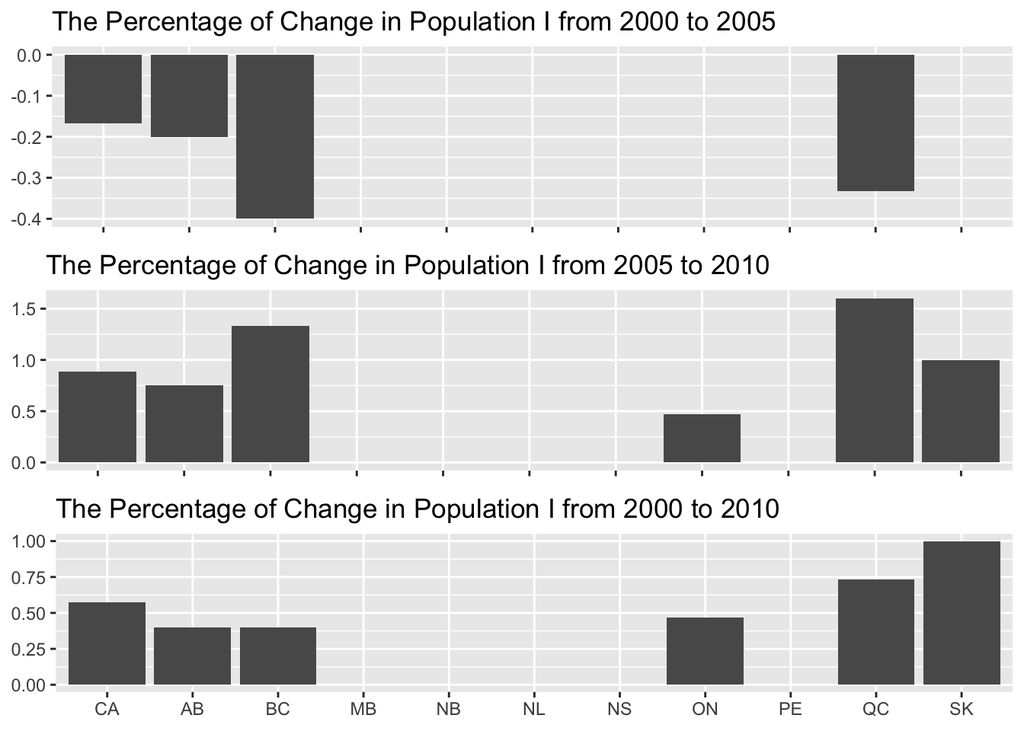

```r
library(gridExtra)

f1 = ggplot(GP1,aes(x=GEO1,y=`C2000-05`)) +
  geom_bar(stat = "identity") +
  theme(axis.title.x=element_blank(),axis.title.y=element_blank(),axis.text.x=element_blank()) +
  labs(title = "The Percentage of Change in Population I from 2000 to 2005")

f2 = ggplot(GP1,aes(x=GEO1,y=`C2005-10`)) +
  geom_bar(stat = "identity") +
  theme(axis.title.x=element_blank(),axis.title.y=element_blank(),axis.text.x=element_blank()) +
  labs(title = "The Percentage of Change in Population I from 2005 to 2010")

f3 = ggplot(GP1,aes(x=GEO1,y=`C2000-10`)) +
  geom_bar(stat = "identity") +
  theme(axis.title.x=element_blank(),axis.title.y=element_blank()) +
  labs(title = "The Percentage of Change in Population I from 2000 to 2010")

grid.arrange(f1,f2,f3,nrow=3)
```

From the above figure, British Columbia had the most $Population\; I$ decrease from 2000 to 2005; Quebec had the most $Population\; I$ growth from 2005 to 2010; and from 2000 to 2010, Saskatchewan had the most $Population\; I$ growth.

The next tables focus on the changes in $Population\; II$.

```r
head(GP2[order(GP2$`C2000-05`),-c(6,8,9)])
```

```
##                 GEO        UOM GEO1 V2000 V2005   C2000-05
## 2           Alberta Percentage   AB    13     9 -0.3076923
## 6            Canada Percentage   CA    11     8 -0.2727273
## 20           Quebec Percentage   QC    17    15 -0.1176471
## 4  British Columbia Percentage   BC     5     5  0.0000000
## 16          Ontario Percentage   ON     5     5  0.0000000
## 8          Manitoba Percentage   MB    NA    NA         NA
```

```r
head(GP2[order(GP2$`C2005-10`,decreasing = T),-c(4,7,9)])
```

```
##                 GEO        UOM GEO1 V2005 V2010  C2005-10
## 6            Canada Percentage   CA     8    16 1.0000000
## 4  British Columbia Percentage   BC     5     9 0.8000000
## 16          Ontario Percentage   ON     5     9 0.8000000
## 20           Quebec Percentage   QC    15    23 0.5333333
## 2           Alberta Percentage   AB     9    10 0.1111111
## 8          Manitoba Percentage   MB    NA    NA        NA
```

```r
head(GP2[order(GP2$`C2000-10`,decreasing = T),-c(5,7,8)])
```

```
##                 GEO        UOM GEO1 V2000 V2010   C2000-10
## 4  British Columbia Percentage   BC     5     9  0.8000000
## 16          Ontario Percentage   ON     5     9  0.8000000
## 22     Saskatchewan Percentage   SK    15    26  0.7333333
## 6            Canada Percentage   CA    11    16  0.4545455
## 20           Quebec Percentage   QC    17    23  0.3529412
## 2           Alberta Percentage   AB    13    10 -0.2307692
```

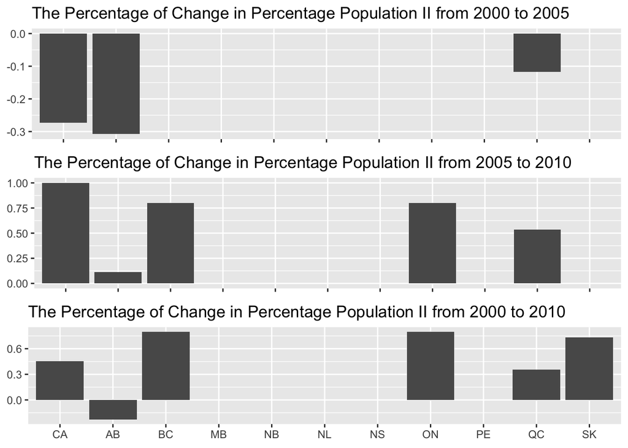

```r
f1 = ggplot(GP2,aes(x=GEO1,y=`C2000-05`)) +
  geom_bar(stat = "identity") +
  theme(axis.title.x=element_blank(),axis.title.y=element_blank(),axis.text.x=element_blank()) +
  labs(title = "The Percentage of Change in Percentage Population II from 2000 to 2005")

f2 = ggplot(GP2,aes(x=GEO1,y=`C2005-10`)) +
  geom_bar(stat = "identity") +
  theme(axis.title.x=element_blank(),axis.title.y=element_blank(),axis.text.x=element_blank()) +
  labs(title = "The Percentage of Change in Percentage Population II from 2005 to 2010")

f3 = ggplot(GP2,aes(x=GEO1,y=`C2000-10`)) +
  geom_bar(stat = "identity") +
  theme(axis.title.x=element_blank(),axis.title.y=element_blank()) +
  labs(title = "The Percentage of Change in Percentage Population II from 2000 to 2010")

grid.arrange(f1,f2,f3,nrow=3)
```

The above figure shows that Alberta had the most population II decrease from 2000 to 2005; however, British Columbia and Ontario shared the most population II growth from 2005 to 2010. In the period of 2000 to 2010, British Columbia and Ontario shared the most population II growth; in the contrast Alberta had a decrease.

It would be interesting to see if there are geographic patterns to the percentage of changes in $Population\; I$ and $II$ in the different provinces.

Recall the map of Canada by province, which can be found in [2016 Census - Boundary files, Statistics Canada](https://www12.statcan.gc.ca/census-recensement/2011/geo/bound-limit/bound-limit-2016-eng.cfm).

```r
library(rgdal)

canada.raw = readOGR(dsn = "~/Downloads/gpr_000b11a_e", layer = "gpr_000b11a_e", use_iconv=TRUE, encoding="CP1250")

library(geojsonio)

canada.raw.json = geojson_json(canada.raw)

library(rmapshaper)

canada.raw.sim = ms_simplify(canada.raw.json)

geojson_write(canada.raw.sim, file = "~/Documents/Maps/canada.geojson")
```

```r
library(sf)
```

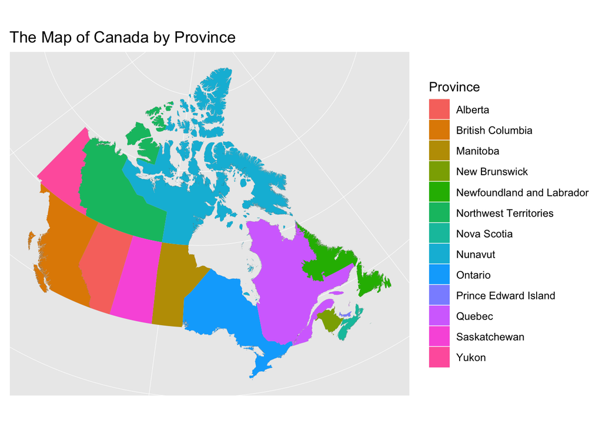

```r
canada.map = st_read(dsn = "~/Documents/Maps/canada.geojson", quiet = TRUE)

canada.map = st_transform(canada.map, crs = "+proj=lcc +lat_1=49 +lat_2=77 +lon_0=-91.52 +x_0=0 +y_0=0 +datum=NAD83 +units=m +no_defs")

names(canada.map)[3] = "Province"

ggplot(data = canada.map, mapping = aes(fill = Province)) +
  geom_sf(size = 0.01) +
  theme(axis.text.x=element_blank(),axis.text.y=element_blank(),axis.ticks.x=element_blank(),axis.ticks.y=element_blank()) +
  labs(title = "The Map of Canada by Province")
```

We provide different groups of $Population\; I$ and $II$ in the year 2010 in maps.

```r
GP1$Gps = cut(GP1$V2010,quantile(GP1$V2010,(0:3)/3),include.lowest = T)

GP1 = subset(GP1, GEO1!="CA")
```

```r
P1 = canada.map

P1$Groups = GP1$Gps[match(canada.map$Province,GP1$GEO)]
```

```r
P1[,c("Province","Groups")]
```

```
## Simple feature collection with 13 features and 2 fields
## geometry type:  MULTIPOLYGON
## dimension:      XY
## bbox:           xmin: -2529065 ymin: 5816874 xmax: 2793734 ymax: 10396190
## epsg (SRID):    NA
## proj4string:    +proj=lcc +lat_1=49 +lat_2=77 +lat_0=0 +lon_0=-91.52 +x_0=0 +y_0=0 +ellps=GRS80 +towgs84=0,0,0,0,0,0,0 +units=m +no_defs
## First 10 features:
##                 Province        Groups                       geometry
## 1       British Columbia     (100,700] MULTIPOLYGON (((-2256493 70...
## 2                 Quebec (700,6.6e+03] MULTIPOLYGON (((1340247 631...
## 3                Nunavut          <NA> MULTIPOLYGON (((752241.2 69...
## 4   Prince Edward Island       [0,100] MULTIPOLYGON (((2144812 674...
## 5           Saskatchewan     (100,700] MULTIPOLYGON (((-565848.3 7...
## 6                  Yukon          <NA> MULTIPOLYGON (((-1616202 93...
## 7               Manitoba       [0,100] MULTIPOLYGON (((-174819.2 7...
## 8                Ontario (700,6.6e+03] MULTIPOLYGON (((760454.6 58...
## 9          New Brunswick       [0,100] MULTIPOLYGON (((1948042 647...
## 10 Northwest Territories          <NA> MULTIPOLYGON (((-1528399 92...
```

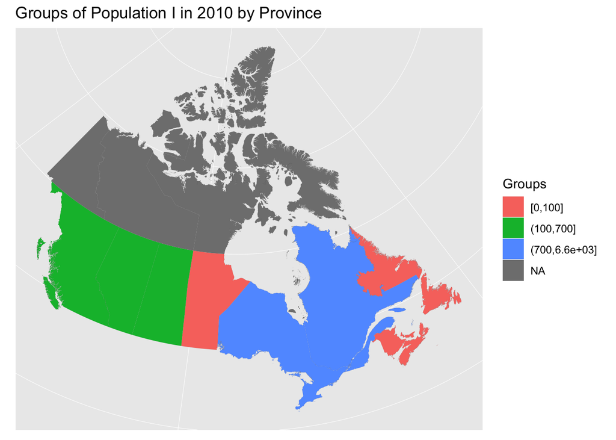

```r
ggplot(data = P1, mapping = aes(fill = Groups)) +
  geom_sf(size = 0.01) +
  theme(axis.text.x=element_blank(),axis.text.y=element_blank(),axis.ticks.x=element_blank(),axis.ticks.y=element_blank()) +
  labs(title = "Groups of Population I in 2010 by Province")
```

```r
GP2$Gps = cut(GP2$V2010,quantile(GP2$V2010,(0:3)/3,na.rm = T),include.lowest = T)

GP2 = subset(GP2, GEO1!="CA")
```

```r
P2 = canada.map

P2$`Groups` = GP2$Gps[match(canada.map$Province,GP2$GEO)]
```

```r
P2[,c("Province","Groups")]
```

```
## Simple feature collection with 13 features and 2 fields
## geometry type:  MULTIPOLYGON
## dimension:      XY
## bbox:           xmin: -2529065 ymin: 5816874 xmax: 2793734 ymax: 10396190
## epsg (SRID):    NA
## proj4string:    +proj=lcc +lat_1=49 +lat_2=77 +lat_0=0 +lon_0=-91.52 +x_0=0 +y_0=0 +ellps=GRS80 +towgs84=0,0,0,0,0,0,0 +units=m +no_defs
## First 10 features:
##                 Province  Groups                       geometry
## 1       British Columbia  [9,10] MULTIPOLYGON (((-2256493 70...
## 2                 Quebec (10,23] MULTIPOLYGON (((1340247 631...
## 3                Nunavut    <NA> MULTIPOLYGON (((752241.2 69...
## 4   Prince Edward Island    <NA> MULTIPOLYGON (((2144812 674...
## 5           Saskatchewan (23,26] MULTIPOLYGON (((-565848.3 7...
## 6                  Yukon    <NA> MULTIPOLYGON (((-1616202 93...
## 7               Manitoba    <NA> MULTIPOLYGON (((-174819.2 7...
## 8                Ontario  [9,10] MULTIPOLYGON (((760454.6 58...
## 9          New Brunswick    <NA> MULTIPOLYGON (((1948042 647...
## 10 Northwest Territories    <NA> MULTIPOLYGON (((-1528399 92...
```

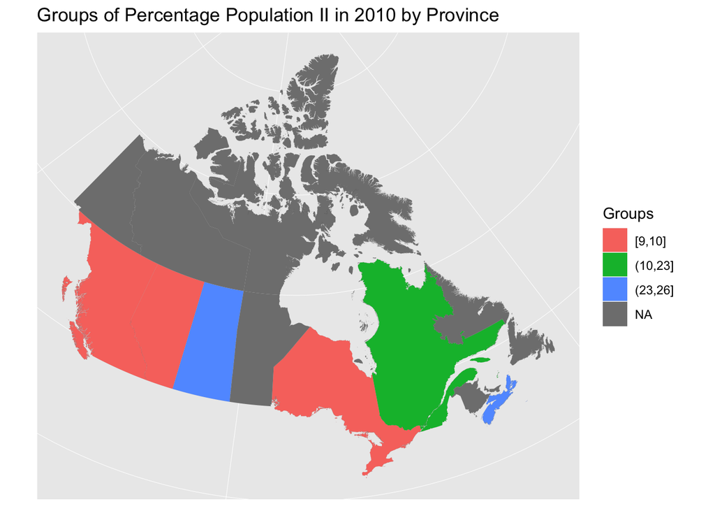

```r
ggplot(data = P2, mapping = aes(fill = `Groups`)) +
  geom_sf(size = 0.01) +
  theme(axis.text.x=element_blank(),axis.text.y=element_blank(),axis.ticks.x=element_blank(),axis.ticks.y=element_blank()) +
  labs(title = "Groups of Percentage Population II in 2010 by Province")
```